# Principal Component Analysis

Liam Abbott

## Analysis

Before beginning principal components analysis on the dataset, it’s useful to visualize the relationships between different variables by looking at a few plots of the data. While not an exhaustive collection of all possible plots between pairs of variables, the plots shown below help visualize the relationships between some of the more strongly correlated pairs of variables in the dataset:

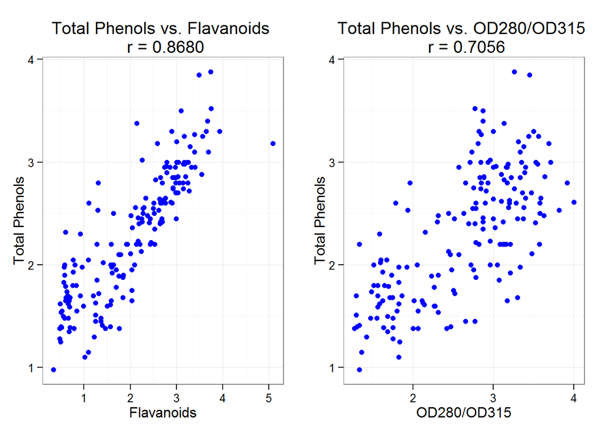

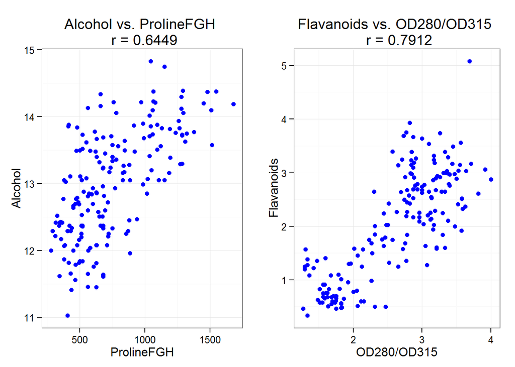

To get an initial understanding of the center and spread of each of the 13 variables in the dataset, it’s useful to look briefly at the mean and standard deviation of each:

| Variable | Mean | Standard Deviation |
| --- | --- | --- |
| Alcohol.content | 12.99 | 0.81 |
| Malic.acid | 2.34 | 1.11 |
| As | 2.37 | 0.27 |
| Alcalinity.in.ash | 19.49 | 3.32 |
| Magnesium | 99.64 | 14.24 |
| Total.phenols | 2.28 | 0.63 |
| Falavanoids | 2.01 | 1.01 |
| Nonflavanoid.phenols | 0.36 | 0.12 |
| Proantocyanins | 1.58 | 0.58 |
| Color.Intensity | 5.09 | 2.33 |
| Hue | 0.95 | 0.23 |
| OD280.OD315 | 2.60 | 0.71 |
| Proline | 744.04 | 314.31 |

As the summary figures above show, the variables in the dataset seem to be measured on different scales and likely with different units.

For this reason, principal components analysis on correlations makes the most sense in this situation. It’s unlikely that there is any valuable information in the variance of the variables that is lost by applying PCA to the correlation matrix rather than the covariance matrix.

Performing PCA on correlations on this dataset produced 13 principal components, each of which explained the following proportions of total variation in the data:

| Principal Component | Percentage of Variation Explained |
| --- | --- |
| 1 | 36.56 |
| 2 | 19.00 |
| 3 | 11.19 |
| 4 | 6.98 |
| 5 | 6.54 |
| 6 | 4.90 |
| 7 | 4.24 |
| 8 | 2.67 |
| 9 | 2.22 |
| 10 | 1.90 |
| 11 | 1.73 |
| 12 | 1.30 |
| 13 | 0.78 |

To visualize the information in the table above about the proportion of variation explained by each principal component, we can look at a scree plot showing the variance of each principal component on the y-axis:

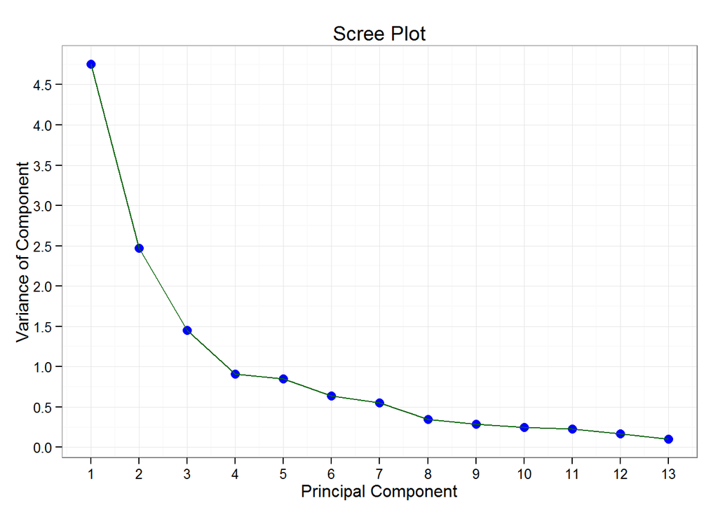

We can look at the same information in a different way by plotting the proportion of total variance in the dataset explained by each principal component and the cumulative proportion of variance explained up to each principal component in the plots below:

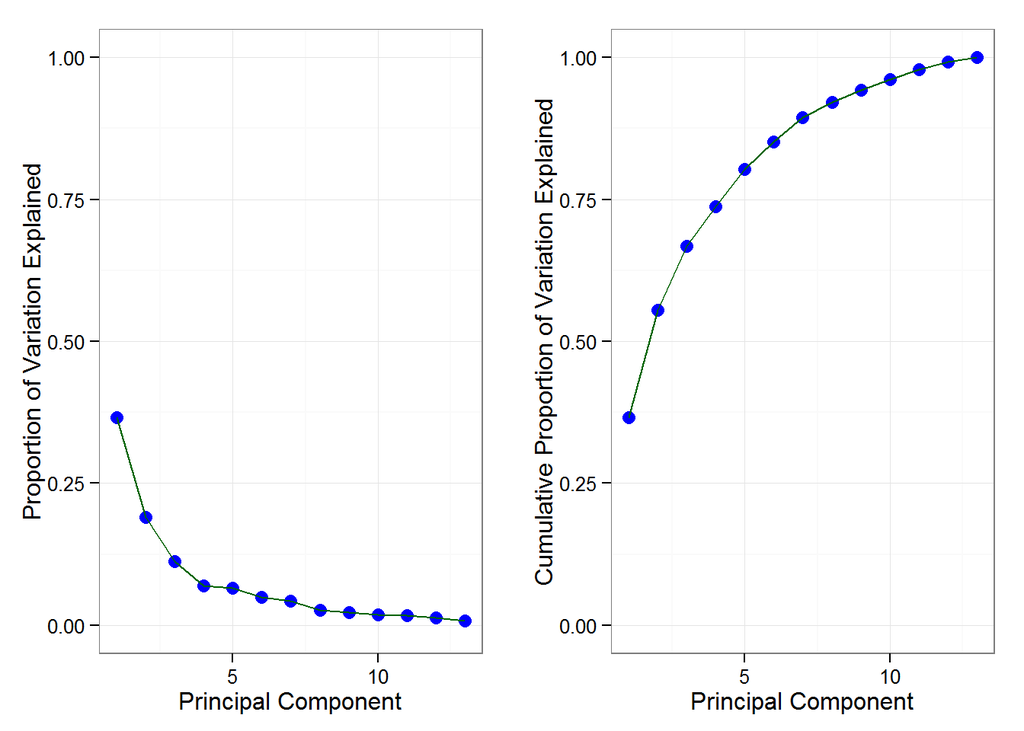

Looking at both the table and plots above, it seems that the first five principal components are the most important in this dataset. Together, they combine to explain about 80% of the variation in the data. Going forward, we will focus the analysis on these first five principal components.

After narrowing the focus to the first five principal components of the data, we can look more closely at the variable loadings of each of these five principal components:

|  | Prin Comp 1 | Prin Comp 2 | Prin Comp 3 | Prin Comp 4 | Prin Comp 5 |
| --- | --- | --- | --- | --- | --- |
| Alcohol.content | -0.1457 | 0.4858 | -0.2038 | -0.0041 | 0.2619 |
| Malic.acid | 0.2428 | 0.2240 | 0.0961 | 0.5501 | -0.0631 |
| As | -0.0007 | 0.3185 | 0.6236 | -0.2089 | 0.1457 |
| Alcalinity.in.ash | 0.2334 | -0.0116 | 0.6160 | 0.0599 | -0.0627 |
| Magnesium | -0.1447 | 0.2997 | 0.1326 | -0.3663 | -0.7206 |
| Total.phenols | -0.3941 | 0.0648 | 0.1415 | 0.2005 | 0.1459 |
| Falavanoids | -0.4217 | -0.0028 | 0.1453 | 0.1547 | 0.1066 |
| Nonflavanoid.phenols | 0.2973 | 0.0294 | 0.1723 | -0.1961 | 0.5084 |
| Proantocyanins | -0.3158 | 0.0375 | 0.1484 | 0.3880 | -0.1343 |
| Color.Intensity | 0.0965 | 0.5280 | -0.1443 | 0.0618 | 0.0834 |
| Hue | -0.3001 | -0.2762 | 0.0878 | -0.4157 | 0.1813 |
| OD280.OD315 | -0.3761 | -0.1631 | 0.1610 | 0.1895 | 0.0940 |
| Proline | -0.2868 | 0.3663 | -0.1267 | -0.2244 | 0.1584 |

From the table above, the first principal component draws fairly equally on many of the variables, including malic acid, alkalinity of ash, total phenols, flavonoids, nonflavanoid phenols, proanthocyanins, hue, OD280/OD315, and prolineFGH.

Below, we can look at a plot of the data projected onto the first two principal components:

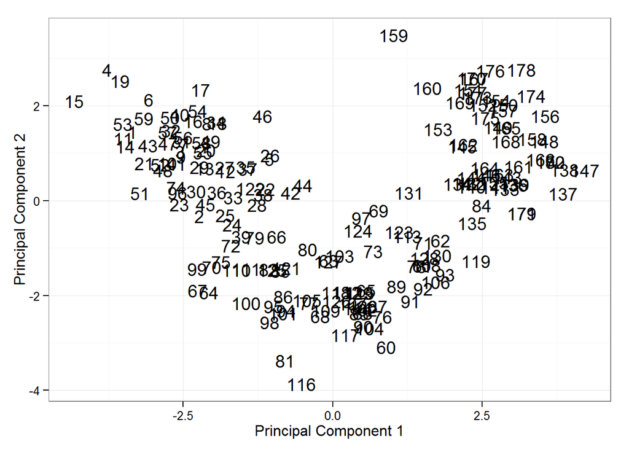

The data generally follows a parabolic shape when projected onto the plot with principal component 1 on the horizontal axis and principal component 2 on the vertical axis.

Wines 81 and 116 in the dataset seem like they may be outliers, as does wine 159. These three points stray from the general pattern the rest of the data seems to be following.

One final plot to look at in this principal component analysis is a biplot showing the original 13 variables projected onto a plot of the first two principal components:

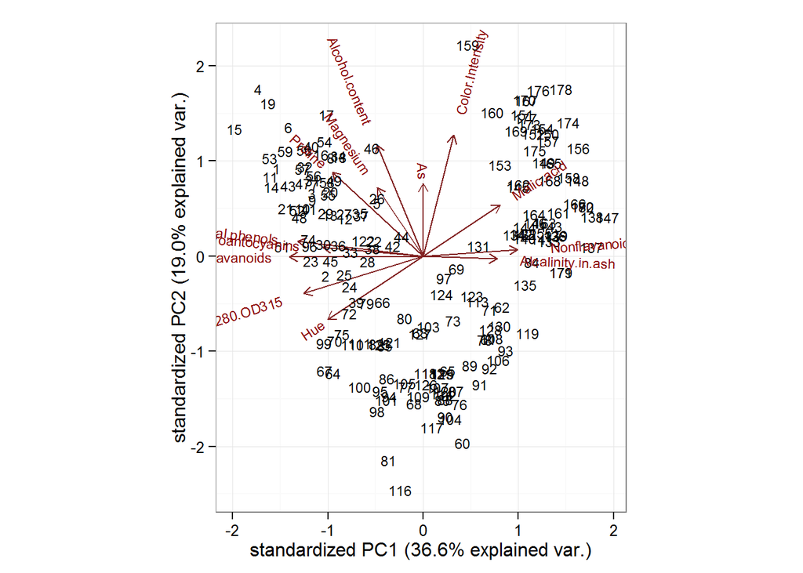

From looking at the biplot, the variables ‘total phenols’, ‘flavanoids’, ‘proanthocyanins’, ‘nonflavanoid phenols’, and ‘alcalinity of ash’ are almost entirely along the first principal component. Meanwhile, ‘ash’, ‘alcohol’, and ‘color intensity’ are mostly along the second principal component.